# Assessing the Role of Age and Cumulative Smoking Exposure in Lung Cancer Risk

Author

Saraa Al Jawad

**Authors**

Saraa Al Jawad

**Author affiliations**

1. Institute of Bioinformatics, University of Georgia, Athens, GA, USA.

# 1 Abstract

Lung cancer remains one of the leading causes of cancer-related mortality worldwide, with age and smoking exposure recognized as major risk factors. Understanding how these factors contribute to lung cancer risk is essential for improving prevention strategies and risk assessment. This analysis investigates the relationship between age, cumulative smoking exposure (pack-years), and lung cancer risk using a dataset of 5,000 individuals with demographic and clinical variables. Logistic regression models were used to assess associations between age, smoking status, cumulative smoking exposure (pack-years), and chronic obstructive pulmonary disease (COPD) with lung cancer risk. Model performance was evaluated using accuracy and area under the receiver operating characteristic curve (AUC). Results showed that both age and cumulative smoking exposure are positively associated with lung cancer risk. However, cumulative smoking exposure (pack-years), which accounts for both duration and intensity of smoking, provides a more stable and informative measure of risk than age or smoking status alone. Incorporating pack-years substantially improved predictive performance, with the AUC increasing from 0.886 to 0.992. While the inclusion of COPD further improved model performance, the gain was minimal. A LASSO model was also evaluated using cross-validation, showing similar performance to logistic regression, indicating that regularization did not improve predictive accuracy.

Overall, these findings demonstrate that while age contributes to lung cancer risk, cumulative smoking exposure plays a stronger role in prediction, highlighting the importance of accounting for long-term smoking behavior in risk assessment models.

# 2 Introduction

## 2.1 General Background Information

Lung cancer is one of the leading causes of cancer-related mortality worldwide and remains a major public health concern (1). Despite advances in screening and treatment, lung cancer often presents at advanced stages, leading to poor prognosis and high mortality rates. Identifying and understanding key risk factors is therefore essential for prevention efforts and early risk assessment.

Approximately 85% of lung cancer cases occur in current or former smokers, underscoring the dominant role of tobacco exposure in disease development (2,3). Long-term cigarette smokers face a substantial cumulative risk of lung cancer, demonstrating a strong dose–response relationship between smoking exposure and disease risk. Beyond smoking alone, risk prediction research has emphasized the importance of incorporating additional clinical and environmental factors to better estimate individual susceptibility. These findings support the need for structured risk assessment approaches that evaluate both smoking history and other relevant predictors when examining lung cancer risk (4).

Age and smoking exposure are well-established risk factors for lung cancer. Risk increases with age due to cumulative biological changes and prolonged exposure to carcinogens over time. Similarly, greater cumulative smoking exposure is strongly associated with increased lung cancer incidence and remains the primary preventable risk factor. Examining these variables together allows for a clearer understanding of how they contribute to disease risk.

In addition to these traditional risk factors, increasing evidence suggests that chronic respiratory diseases, particularly chronic obstructive pulmonary disease (COPD), play a significant role in lung cancer development. COPD is not only a common comorbidity in lung cancer patients but is also considered an independent risk factor for lung cancer, even after adjusting for smoking history (5,6). Individuals with impaired lung function or airflow obstruction have been shown to have a significantly higher likelihood of developing lung cancer compared to those with normal lung function. This relationship suggests that COPD and lung cancer may share common biological mechanisms rather than being solely linked through smoking exposure.

Several underlying mechanisms have been proposed to explain this association. Chronic inflammation in COPD creates a pro-tumor microenvironment characterized by persistent immune activation and cytokine release, which can promote tumor initiation and progression. In addition, oxidative stress caused by cigarette smoke and inflammatory processes leads to DNA damage, genomic instability, and impaired DNA repair mechanisms, all of which contribute to carcinogenesis. Genetic susceptibility and epigenetic modifications further link the two diseases, with shared genetic loci and altered gene expression patterns observed in both COPD and lung cancer (7). Moreover, only a subset of smokers develop either COPD or lung cancer, indicating that additional factors such as genetic predisposition, aging, and environmental influences play a critical role in disease development.

## 2.2 Smoking Exposure and Risk Measurement

Smoking exposure is commonly quantified using pack-years, which integrates both the duration and intensity of smoking and provides a comprehensive measure of cumulative exposure. Epidemiological studies have shown that lung cancer risk is strongly associated with total smoking exposure, with approximately linear increases in risk observed with increasing pack-years (8). The use of pack-years allows for a more accurate representation of cumulative risk compared to binary measures such as smoking status alone.

Importantly, evidence suggests that for equivalent total exposure, smoking at lower intensity over a longer duration may be more harmful than higher-intensity smoking over a shorter period, highlighting the critical role of long-term exposure in lung cancer development (9) . This finding emphasizes that both duration and cumulative exposure are essential components in understanding lung cancer risk and supports the use of pack-years as a key predictor in risk modeling.

Together, these findings highlight the importance of integrating multiple predictors, such as age, cumulative smoking exposure, and additional clinical factors into analytical models to better capture the complexity of lung cancer risk and improve predictive performance. To investigate these relationships in the present study, we analyzed a dataset containing individual-level information on lung cancer risk factors and disease status.

This study examines the relationship between age and cumulative smoking exposure (pack-years) in predicting lung cancer risk. We hypothesize that both age and cumulative smoking exposure are positively associated with lung cancer risk, and that cumulative smoking exposure provides a stronger and more informative predictor than age when both variables are considered together.

## 2.3 Description of data and data source

The data used in this analysis consist of individual-level observations on lung cancer risk factors and disease status. The dataset contains 5,000 observations and 30 variables, including demographic characteristics, smoking-related variables, and clinical indicators.

The primary variables of interest in this study are age, smoking status, cumulative smoking exposure (pack-years), and lung cancer status. COPD was included as an additional clinical variable to assess whether it provides further information beyond age and smoking exposure.

# 3 Methods

## 3.1 Data acquisition

The dataset used in this analysis was obtained from a publicly available online source and downloaded in CSV format. The dataset contains individual-level information on lung cancer risk factors and disease status, including demographic and smoking-related variables.

## 3.2 Data import and cleaning

The dataset was imported from a CSV file stored in the project repository. Basic cleaning steps were performed to ensure key variables were in the correct format for analysis. Specifically, age and cumulative smoking exposure (pack-years) were converted to numeric variables, and lung cancer status, smoking status, and COPD were treated as categorical variables (factors). The cleaned dataset was used for all descriptive summaries and figures.

## 3.3 Statistical analysis

Exploratory data analysis was conducted to examine the distributions of key variables and identify potential patterns or relationships between age, smoking exposure, and lung cancer status. Summary statistics and simple visualizations were used to better understand the data and assess data quality.

Logistic regression models were applied to evaluate the association between age, smoking-related variables, and lung cancer risk. Both smoking status and cumulative smoking exposure (pack-years) were evaluated as predictors. Logistic regression models were used to assess the independent and combined effects of these predictors on lung cancer outcomes. Cumulative smoking exposure (pack-years) was specifically evaluated as a key predictor in multivariable models, as it provides a more detailed measure of smoking history compared to smoking status alone.

In an extended multivariable analysis, COPD was also evaluated as an additional clinical predictor to determine whether it contributed independent information beyond age and cumulative smoking exposure.

## 3.4 Predictive modeling and model evaluation

To complement the statistical analysis, a predictive modeling workflow was implemented in R using the tidymodels framework. Logistic regression was used to compare three models with increasing complexity: (1) age and smoking status, (2) age and cumulative smoking exposure (pack-years), and (3) age, pack-years, and COPD.

The dataset was split into training (75%) and testing (25%) sets using stratified sampling based on lung cancer risk. Models were fitted on the training set and evaluated on the independent test set. Predictive performance was assessed using accuracy, sensitivity, specificity, and area under the receiver operating characteristic curve (AUC). In addition, 5-fold cross-validation was performed on the training data to assess model stability and reduce the risk of overfitting. Model performance metrics were computed on the test set to evaluate generalization performance. This approach allows for a consistent comparison of model performance and ensures that results are not driven by overfitting.

In addition to logistic regression, a LASSO model was implemented to apply regularization and assess whether constraining model coefficients improves predictive performance. The penalty parameter was tuned using 5-fold cross-validation on the training data. Model performance was evaluated using accuracy and AUC, consistent with the evaluation approach used for the logistic regression models.

# 4 Results

## 4.1 Descriptive analysis

Table 1 summarizes the key characteristics of participants stratified by lung cancer risk. Individuals with lung cancer were slightly older (median age 56 years) compared to those without lung cancer (median age 54 years). The interquartile ranges of age were nearly identical between groups, indicating comparable variability in age distribution.

Smoking exposure differed substantially between groups. The median cumulative smoking exposure (pack-years) among individuals without lung cancer was 0, whereas individuals with lung cancer had a median of 19 pack-years. This indicates markedly higher lifetime smoking exposure among those with lung cancer.

The proportion of smokers was considerably higher in the lung cancer group compared to the non-cancer group. Similarly, the prevalence of COPD was substantially greater among individuals with lung cancer.

Overall, smoking-related variables demonstrated more pronounced differences between groups than age alone.

Table 1: Summary of key variables by lung cancer risk.

| Risk | N | Median Age | IQR Age | Median Pack-Years | IQR Pack-Years | % Smokers | % COPD |
| --- | --- | --- | --- | --- | --- | --- | --- |
| No | 3,756 | 54 | 16 | 0 | 0 | 27.42 | 2.96 |
| Yes | 1,244 | 56 | 15 | 19 | 12 | 100.00 | 55.14 |

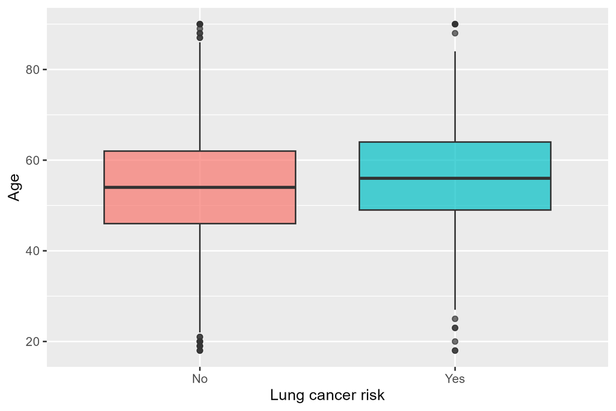

Figure 1: Age distribution by lung cancer risk.

Figure 1 illustrates the distribution of age by lung cancer risk. Although there is overlap between groups, the median age appears slightly higher among individuals with lung cancer. The overall spread of ages is comparable across both groups.

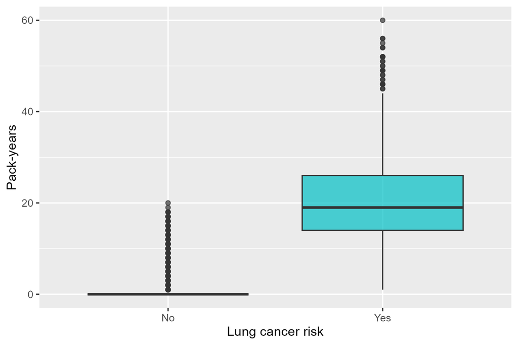

Figure 2: Cumulative smoking exposure (pack-years) by lung cancer risk.

Figure 2 shows the distribution of cumulative smoking exposure by lung cancer risk. Individuals with lung cancer demonstrate substantially higher pack-years compared to those without lung cancer. The non-cancer group shows a large proportion of individuals with zero pack-years, whereas the lung cancer group exhibits a broader distribution with higher median exposure.

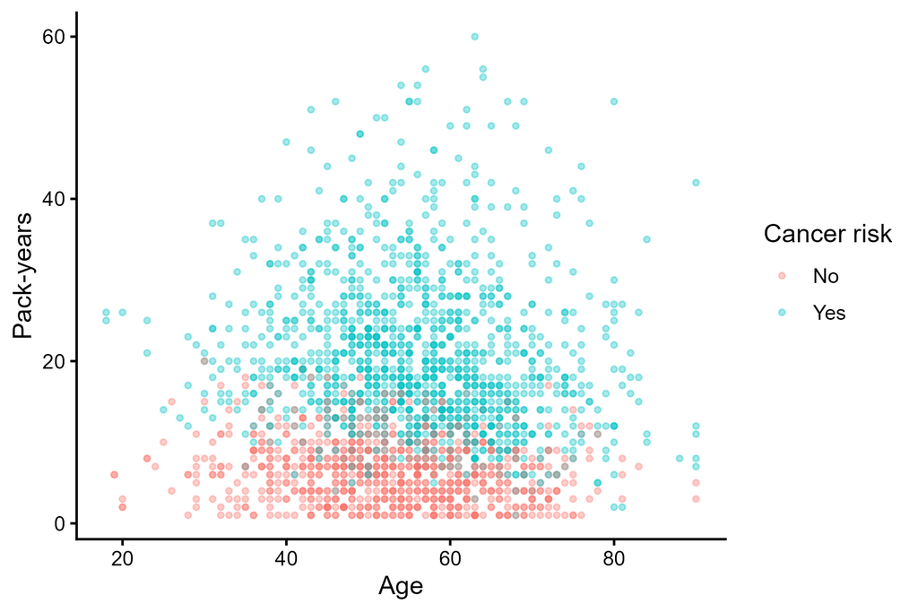

Figure 3: Relationship between age and pack-years by lung cancer risk.

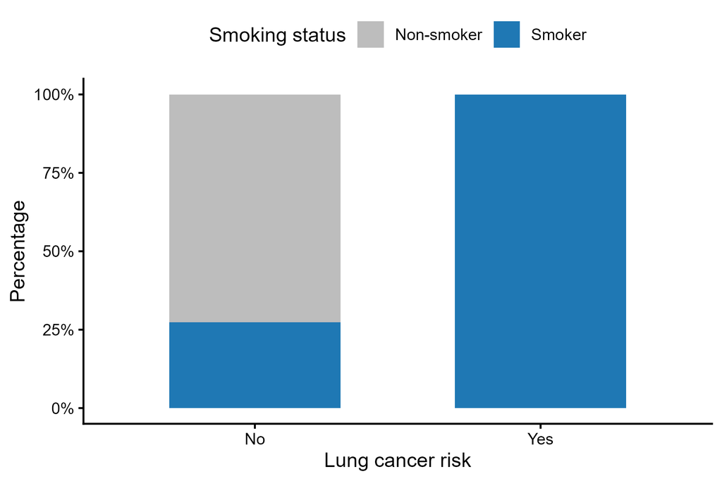

Figure 4: Percentage of smokers by lung cancer risk.

Figure 4 shows the percentage of smokers by lung cancer risk. In this dataset, all individuals classified as having lung cancer were smokers, whereas approximately 27% of individuals without lung cancer were smokers. This indicates a strong association between smoking status and lung cancer in the dataset.

## 4.2 Regression analysis

To further examine associations between predictors and lung cancer risk, logistic regression models were fitted. A model including age as the only predictor showed that age was significantly associated with lung cancer risk (β = 0.016, p < 0.001). This indicates that increasing age is associated with a higher probability of lung cancer. A multivariable model including both age and smoking status was also fitted. In this model, age remained a statistically significant predictor. Smoking status was also evaluated as a predictor of lung cancer risk. While smoking status showed a strong association in descriptive analysis, it resulted in an extremely large coefficient with a very large standard error and was not statistically significant (p = 0.92) in the regression model. This suggests instability in the model, likely due to strong separation in the smoking variable, as all individuals with lung cancer in this dataset were smokers. To better capture smoking-related effects, cumulative smoking exposure (pack-years) was used instead of smoking status in a multivariable model. In this model, both age and pack-years were strongly associated with lung cancer risk. Pack-years showed a large and statistically significant effect (β = 0.53, p < 0.001), indicating that greater cumulative smoking exposure substantially increases lung cancer risk.

Overall, these results suggest that while smoking status is strongly associated with lung cancer, cumulative smoking exposure (pack-years) provides a more stable and informative predictor in regression modeling. To further illustrate this relationship, predicted lung cancer risk was evaluated as a function of cumulative smoking exposure while holding age constant at its median value (Figure 6). The probability of lung cancer increases sharply as pack-years increase, highlighting the strong effect of cumulative smoking exposure on disease risk.

A further multivariable model including age, pack-years, and COPD showed that COPD was also significantly associated with lung cancer risk after adjustment for age and cumulative smoking exposure. In this model, individuals with COPD had substantially higher odds of lung cancer compared with those without COPD (OR = 5.30, 95% CI: 3.66–7.75, p < 0.001). Although the addition of COPD improved the model, cumulative smoking exposure remained the strongest predictor overall.

Table 2: summarizes the multivariable logistic regression results for age, pack-years, and COPD.

| Variable | Odds Ratio | 95% CI | p-value |
| --- | --- | --- | --- |
| Age | 1.09 | 1.08–1.11 | <0.001 |
| Pack-years | 1.68 | 1.61–1.75 | <0.001 |
| COPD | 5.30 | 3.66–7.75 | <0.001 |

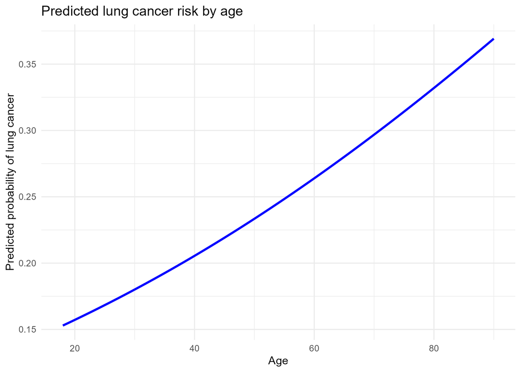

Figure 5: Predicted probability of lung cancer risk by age.

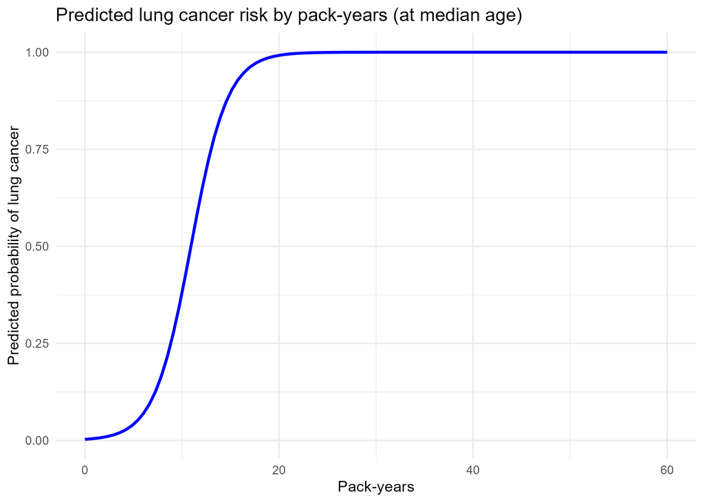

Figure 6: Predicted lung cancer risk as a function of pack-years, with age held constant at its median value.

## 4.3 Predictive modeling results

Three logistic regression models were evaluated to assess the contribution of smoking-related variables and COPD to lung cancer risk prediction. Model performance improved when cumulative smoking exposure (pack-years) was used instead of smoking status, indicating that pack-years provides a more informative measure of smoking-related risk. The AUC increased from 0.886 in the smoking status model to 0.992 in the pack-years model, demonstrating a marked gain in predictive ability.

The addition of COPD to the model resulted in only a modest improvement in predictive performance compared to the model including age and pack-years alone. The inclusion of COPD led to only a minimal additional increase in AUC (0.993).

Table 3: Comparison of predictive performance across logistic regression models.

| Model | Accuracy | Sensitivity | Specificity | AUC |
| --- | --- | --- | --- | --- |
| Age + Smoking Status | 0.806 | 0.814 | 0.785 | 0.886 |
| Age + Pack-Years | 0.954 | 0.968 | 0.910 | 0.992 |
| Age + Pack-Years + COPD | 0.955 | 0.972 | 0.904 | 0.993 |

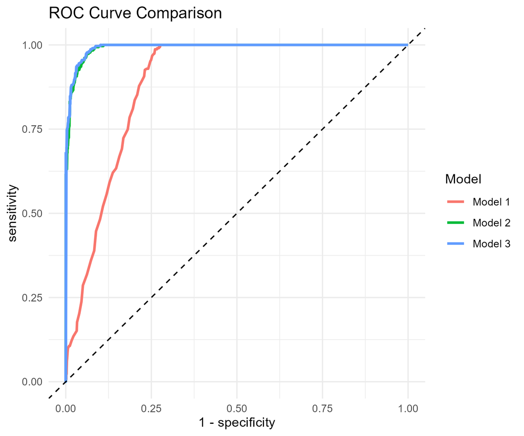

Figure 7: ROC curves for the three models

Figure 7 shows the ROC curves for the three models, illustrating the improvement in predictive performance when pack-years is used instead of smoking status, with only minimal additional gain from including COPD.

## 4.4 Comparison with LASSO Model

Table 4: Comparison of predictive performance between the final logistic regression model and the LASSO model.

| Model | Accuracy | AUC |
| --- | --- | --- |
| Logistic (Model 3) | 0.955 | 0.993 |
| LASSO | 0.955 | 0.993 |

# 5 Discussion

## 5.1 Summary and Interpretation

In this study, we evaluated the association between age, cumulative smoking exposure, and lung cancer risk using both statistical and predictive modeling approaches. The results consistently showed that cumulative smoking exposure (pack-years) is a strong and reliable predictor of lung cancer risk, outperforming smoking status alone. While age was also associated with increased risk, its effect was smaller compared to cumulative smoking exposure.

The predictive modeling analysis further demonstrated that replacing smoking status with pack-years substantially improved model performance, as reflected by higher accuracy and AUC values. Although the inclusion of COPD provided additional predictive information, its contribution was relatively modest compared to pack-years. Overall, these findings highlight the importance of using detailed measures of smoking exposure when assessing lung cancer risk.

The comparison between logistic regression and the LASSO model further confirmed these findings, as both approaches yielded identical predictive performance. This suggests that the relationship between predictors and lung cancer risk is relatively simple and does not require more complex modeling approaches.

## 5.2 Strengths and Limitations

A key strength of this analysis is the use of multiple complementary approaches, including exploratory analysis, statistical modeling, and predictive modeling, to evaluate lung cancer risk factors. The use of cumulative smoking exposure (pack-years) enable for a more detailed and informative assessment of smoking-related risk compared to binary smoking status. Additionally, the implementation of train/test splitting and cross-validation improves the robustness of the predictive modeling results.

However, several limitations should be considered. The dataset is observational, which limits the ability to draw causal conclusions. In addition, the smoking status exhibited strong separation, as all individuals with lung cancer were smokers, leading to instability in regression models using this variable alone. The analysis was also limited to the available variables and did not include other potential risk factors such as environmental exposures or genetic predisposition. Finally, while the predictive models were relatively simple, the inclusion of a LASSO model demonstrated that more complex or regularized approaches did not provide additional benefit for this dataset.

## 5.3 Conclusions

This analysis demonstrates that cumulative smoking exposure is the primary driver of lung cancer risk and provides a more informative predictor than smoking status alone. While age contributes to risk, its effect is smaller relative to smoking exposure. The inclusion of COPD offers additional predictive value, but its contribution is limited compared to pack-years.

These findings emphasize the importance of incorporating detailed smoking exposure measures in both statistical and predictive models for lung cancer risk assessment. Future work could explore additional predictors and more advanced modeling approaches to further improve risk prediction.

Additionally, the comparison with a LASSO model suggests that logistic regression is sufficient for capturing the relationship between predictors and lung cancer risk in this dataset.

# 6 Supplementary materials

The raw dataset used in this analysis is stored in the project repository `data/raw-data/` directory. Processed datasets generated during data cleaning and preprocessing are available in `data/processed-data/`. All analysis steps, including data cleaning, exploratory analysis, model fitting, and evaluation, are documented in reproducible R scripts and Quarto files located in the`code/` directory.

Output files, including tables and figures used in the manuscript, are stored in the `results/` directory, organized into subfolders for tables and figures.

Additional figures and supporting results are provided in the Supplementary Material.

## 7 References

1.

Siegel RL, Giaquinto AN, Jemal A. [Cancer statistics, 2024](https://doi.org/10.3322/caac.21820). *CA: A Cancer Journal for Clinicians*. 2024;74(1):12–49.

2.

Thun MJ, Carter BD, Feskanich D, et al. [50-year trends in smoking-related mortality in the united states](https://doi.org/10.1056/NEJMsa1211127). *New England Journal of Medicine*. 2013;368(4):351–364.

3.

Jha P, Ramasundarahettige C, Landsman V, et al. [21st-century hazards of smoking and benefits of cessation in the united states](https://doi.org/10.1056/NEJMsa1211128). *New England Journal of Medicine*. 2013;368(4):341–350.

4.

Spitz MR, Hong WK, Amos CI, et al. [A risk model for prediction of lung cancer](https://doi.org/10.1093/jnci/djk153). *Journal of the National Cancer Institute*. 2007;99(9):715–726.

5.

Durham AL, Adcock IM. The relationship between COPD and lung cancer. *Lung Cancer*. 2015;90(2):121–127.

6.

Young RP, Hopkins RJ, Christmas T, et al. [COPD prevalence is increased in lung cancer, independent of age, sex and smoking history](https://doi.org/10.1183/09031936.00144208). *European Respiratory Journal*. 2009;34(2):380–386.

7.

Qi C, Sun S-W, Xiong X-Z. From COPD to lung cancer: Mechanisms linking, diagnosis, treatment, and prognosis. *International Journal of Chronic Obstructive Pulmonary Disease*. 2022;17:2603–2621.

8.

Kenfield SA, Wei EK, Stampfer MJ, et al. [Comparison of aspects of smoking among the four histological types of lung cancer](https://doi.org/10.1093/jnci/djn214). *Journal of the National Cancer Institute*. 2008;100(16):1209–1220.

9.

Lubin JH, Caporaso NE. Cigarette smoking and lung cancer: Modeling total exposure and intensity. *Cancer Epidemiology Biomarkers & Prevention*. 2006;15(3):517–523.